# R Wykresy

dr Magdalena Guzowska

# Wykresy - podstawy

## Wykresy typu plot

Funkcja `plot` służy do zobrazowania danych zapisanych w wektorach, macierzach, szeregach czasowych i bardziej skomplikowanych strukturach, których elementami są wektory. W najprostszej wersji, gdy zastosujemy ją na pojedynczym wektorze x pojawi się wykres pokazujący rozrzut punktów o współrzędnych (i, x[i]).

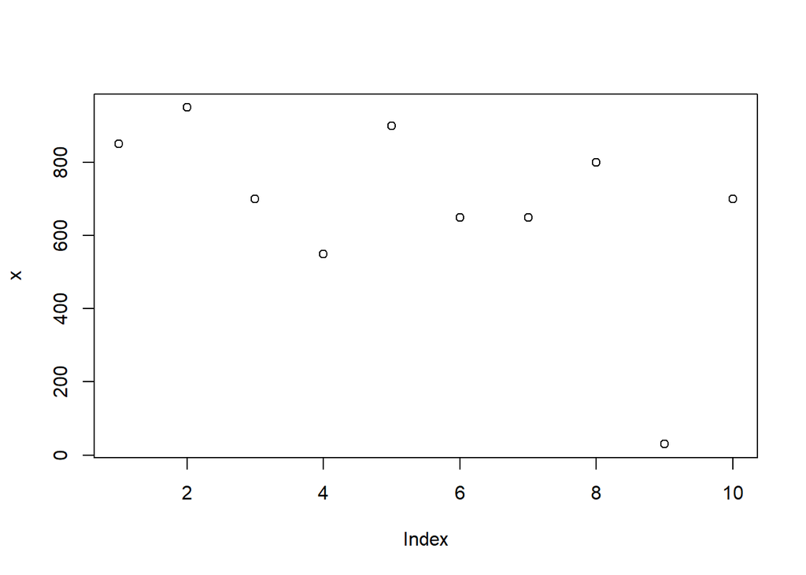

```r
x=c(850, 950, 700, 550, 900, 650, 650, 800, 30, 700)
plot(x)
```

Wykresy **typu plot** inaczej działają, gdy wprowadzi się do nich ciąg liczbowy a inaczej, gdy działają na obiekcie typu factor

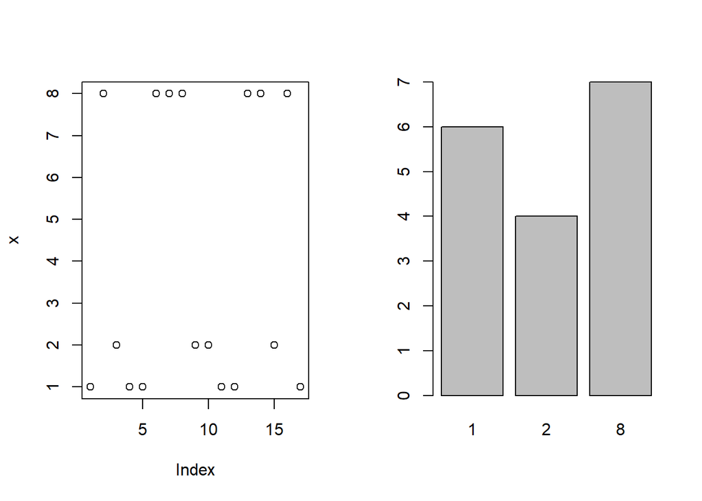

```r
par(mfrow=c(1,2))
x=c(1, 8, 2, 1, 1, 8, 8, 8, 2, 2, 1, 1, 8, 8, 2, 8, 1)
plot(x)
plot(factor(x))
```

Jeszcze inny typ wykresu powstanie gdy argumentami funkcji `plot` są dwa wektory, czynnik i wektor oraz dwa czynniki.

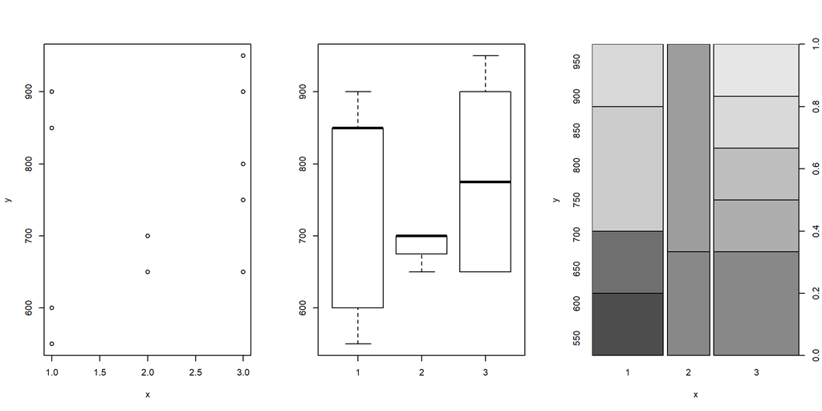

```r
par(mfrow=c(1,3))
y=c(850, 950, 700, 550, 900, 650, 650, 800, 650, 700, 600, 850, 900, 750)
x=c(1, 3, 2, 1, 1, 3, 3, 3, 2, 2, 1, 1, 3, 3)
plot(x,y)
plot(factor(x),y)
plot(factor(x),factor(y))
```

Funkcja `plot` służy także do tworzenia wykresów liniowych, punktowo-liniowych, schodkowych, kreskowych za pomocą opcji `type=`. Wartościami tej opcji są symbole literowe napisane w cudzysłowie.

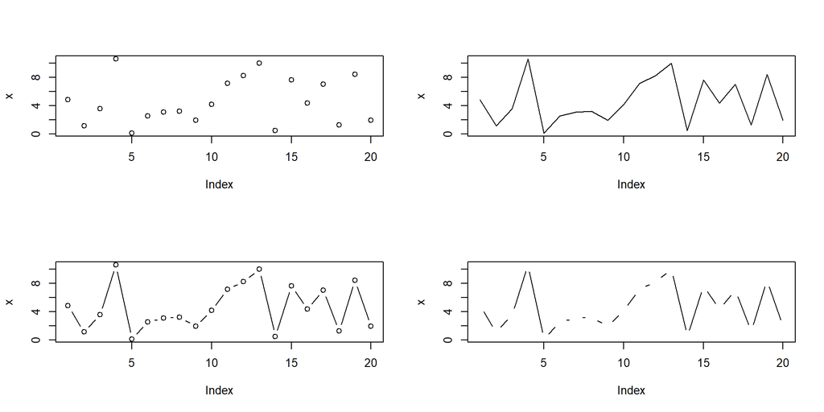

```r
par(mfrow=c(2,2))
x=c(4.84, 1.12, 3.57, 10.57, 0.12, 2.55, 3.10, 3.18, 1.93, 4.15, 7.11, 8.22, 9.96, 0.50, 7.62, 4.33, 7.03, 1.28, 8.42, 1.96)
plot(x,type="p")
plot(x,type="l")
plot(x,type="b")
plot(x,type="c")
```

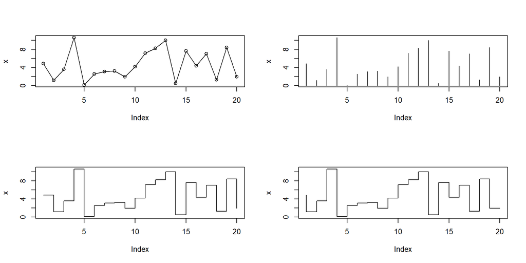

```r
plot(x,type="o")
plot(x,type="h")
plot(x,type="s")
plot(x,type="S")
```

Przy rysowaniu wykresu rozrzutu punktów (x[i],y[i]) można zastosować skalę logarytmiczną o podstawie 10.

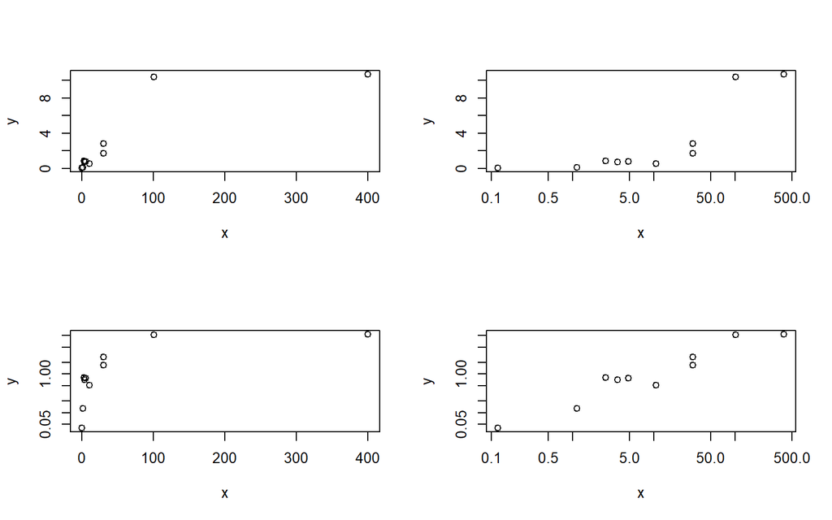

```r
par(mfrow=c(2,2))
x=c(4.84, 1.12, 3.57, 10.57, 0.12, 2.55, 30.10, 30.18, 100.93, 400.15)
y=c(0.77, 0.13, 0.71, 0.51, 0.04, 0.82, 1.70, 2.80, 10.37, 10.67)
plot(x, y)
plot(x, y, log="x")
plot(x, y, log="y")
plot(x, y, log="xy")
```

## Funkcja matplot()

W biologii często wykonuje się pomiary zmiennej Y przy określonych z góry wartościach zmiennej X. Jeżeli tego typu eksperyment powtarza się w kilku wariantach (ale dla takich samych wartości zmiennej X) to uzyskane wyniki można zapisać w macierzy. Zobrazowanie tych wyników w postaci punktów o różnych kolorach lub znacznikach, albo różnych linii najwygodniej wykonać za pomocą funkcji `matplot`.

Standardowo funkcja `matplot` w miejsce wartości stawia numer kolumny, z której pochodzą dane. Opcja `pch=` o wartościach od 1 do 20 w miejsce to stawia znacznik o określonym kształcie. Opcja `type=` może mieć wartości “p”,“l”,“b”,“c”, “o”, “h”, “s”, “S”, “n” i zmienia typ wykresu tak samo jak w funkcji `plot`.

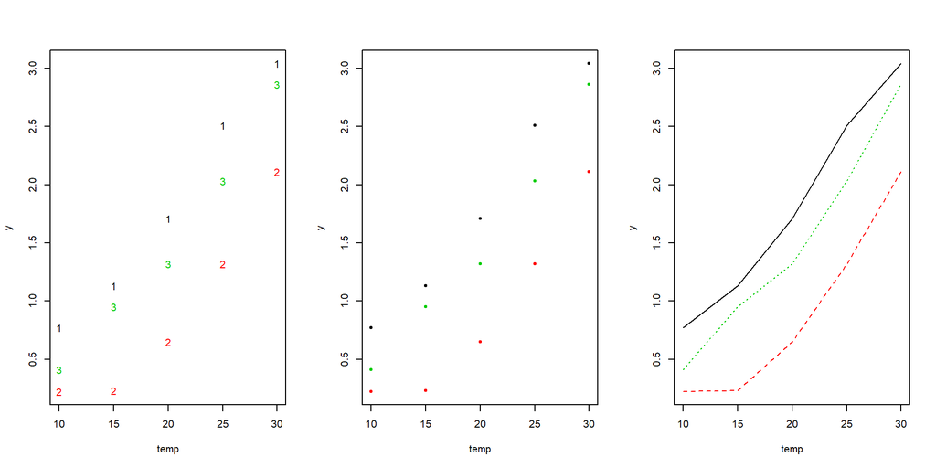

```r
par(mfrow=c(1,3))
temp=c(10, 15, 20, 25, 30)
y1=c(0.77, 1.13, 1.71, 2.51, 3.04)
y2=c(0.22, 0.23, 0.65, 1.32, 2.11)
y3=c(0.41, 0.95, 1.32, 2.03, 2.86)
y=cbind(y1,y2,y3)
matplot(temp, y)
matplot(temp, y, pch=20)
matplot(temp, y, type="l")
```

Jeżeli mierzymy dla tych samych obiektów dwie zmienne X i Y (np. długość i masę) a obiekty pochodzą z trzech populacji statystycznych wartości zmiennej X możemy zapisać w jednej macierzy, a zmiennej Y w drugiej. Wtedy funkcja `matplot` odpowiednio przyporządkowuje dane do siebie.

```r
par(mfrow=c(1,3))
x <- c(0.34, 0.07, 0.02, 0.39, 0.20, 0.06, 0.57, 0.41, 0.22, 0.62, 0.59, 0.59, 0.75, 0.88, 0.96)
x <- matrix(x, nrow = 5, ncol = 3, byrow = TRUE)
x
```

```
##      [,1] [,2] [,3]
## [1,] 0.34 0.07 0.02
## [2,] 0.39 0.20 0.06
## [3,] 0.57 0.41 0.22
## [4,] 0.62 0.59 0.59
## [5,] 0.75 0.88 0.96
```

```r
y <- c(0.77, 0.22, 0.41, 1.13, 0.23, 0.95, 1.71, 0.65, 1.32, 2.51, 1.32, 2.03, 3.04, 2.11, 2.86)
y <- matrix(y, nrow = 5, ncol = 3, byrow = TRUE)
y
```

```
##      [,1] [,2] [,3]
## [1,] 0.77 0.22 0.41
## [2,] 1.13 0.23 0.95
## [3,] 1.71 0.65 1.32
## [4,] 2.51 1.32 2.03
## [5,] 3.04 2.11 2.86
```

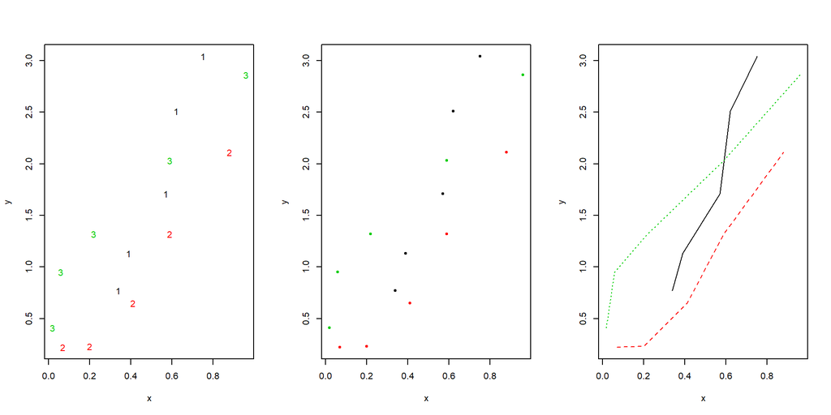

```r
matplot(x, y)
matplot(x, y, pch=20)
matplot(x, y, type="l")
```

## Wykresy kołowy (*ang. pie*)

Jeżeli w jednym zgrupowaniu zakwalifikujemy obiekty do kilku kategorii zwyczajowo podaje się procent obiektów należących do pierwszej, drugiej, n-tej kategorii. Jednym z najpopularniejszym sposobem obrazowania wyników takich badań jest podział koła na części o powierzchni proporcjonalnej do procentu obiektów należących do danej kategorii. W R służy do tego funkcja `pie`. Jest to funkcja, która odpowiedni procent sama wylicza dla dowolnego ciągu.

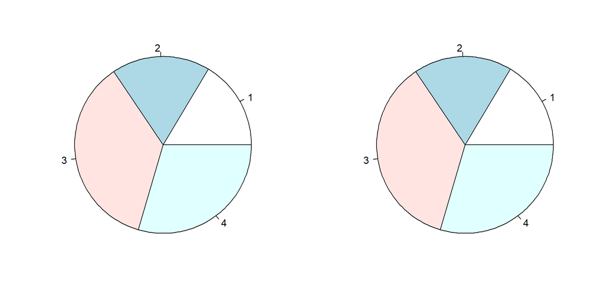

```r
par(mfrow=c(1,2))
N=c(10,11,22,18)
proc=N/sum(N)*100
pie(N, radius = 1)
pie(proc, radius = 1)
```

## Wykresy słupkowe (*ang. barplot*)

Liczbę lub procent wyróżnionych obiektów w różnych zgrupowaniach zazwyczaj pokazuje się na wykresach słupkowych. Gdy dysponujemy tego typu danymi, możemy wykonać wykres słupkowy używając funkcji `barplot`. Dla wektora liczbowego funkcja `barplot` tworzy szereg słupków o wysokości określonej przez podane liczby. Ich interpretacja zależy od sposobu przygotowania danych.

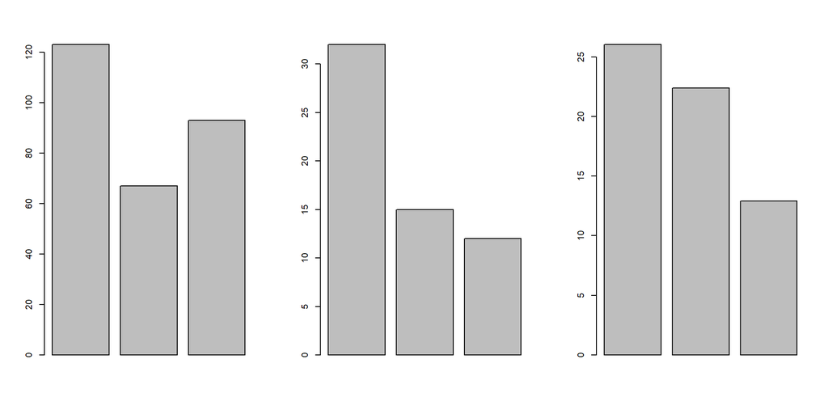

```r
par(mfrow=c(1,3))
N=c(123, 67, 93)
A=c(32, 15,12)
proc=A/N*100
barplot(N)
barplot(A)
barplot(proc)
```

Funkcja `barplot` działa także na macierzach liczbowych. Tworzy wtedy słupki o wysokości równej sumie liczb w poszczególnych kolumnach, których części o długości równej poszczególnym liczbom w kolumnach są inaczej zaciemnione.

```r
par(mfrow=c(1,2))
mat=matrix(1:12,3,4)
mat
```

```
##      [,1] [,2] [,3] [,4]
## [1,]    1    4    7   10
## [2,]    2    5    8   11
## [3,]    3    6    9   12
```

```r
barplot(mat)
mat1=matrix(1:12,3,4,byrow=TRUE)
mat1
```

```
##      [,1] [,2] [,3] [,4]
## [1,]    1    2    3    4
## [2,]    5    6    7    8
## [3,]    9   10   11   12
```

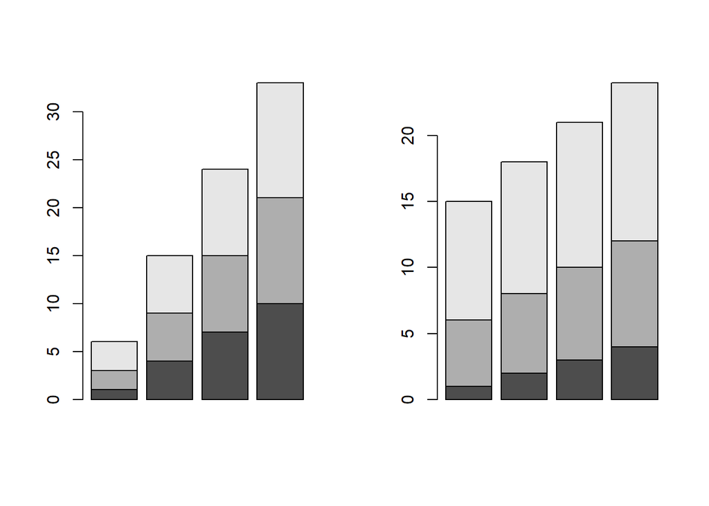

```r
barplot(mat1)
```

Opcja logiczna beside=TRUE powoduje, że części słupków związane z daną liczbą w macierzy są zestawiane obok siebie.

```r
par(mfrow=c(1,2))
mat=matrix(1:12,3,4)
mat
```

```
##      [,1] [,2] [,3] [,4]
## [1,]    1    4    7   10
## [2,]    2    5    8   11
## [3,]    3    6    9   12
```

```r
barplot(mat, beside=TRUE)
mat1=matrix(1:12,3,4,byrow=TRUE)
mat1
```

```
##      [,1] [,2] [,3] [,4]
## [1,]    1    2    3    4
## [2,]    5    6    7    8
## [3,]    9   10   11   12
```

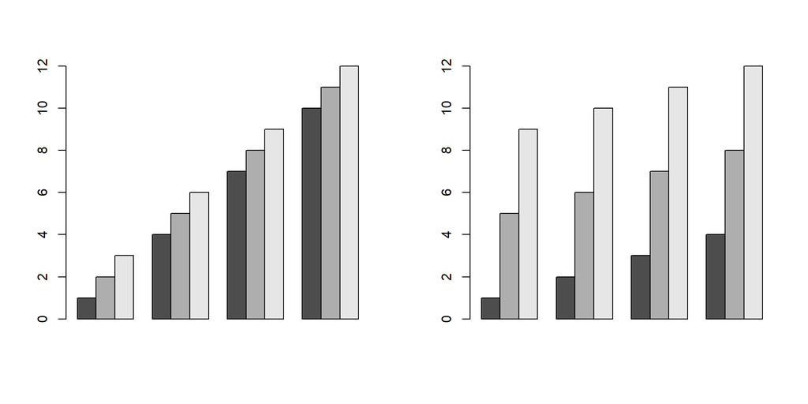

```r
barplot(mat1, beside=TRUE)
```

Funkcja `barplot` umożliwia także robienie wykresów słupkowych ułożonych poziomo, dzięki opcji logicznej `horiz=` (standardowo o wartości FALSE). Po zmianie jej wartości na TRUE powstanie wykres o orientacji poziomej.

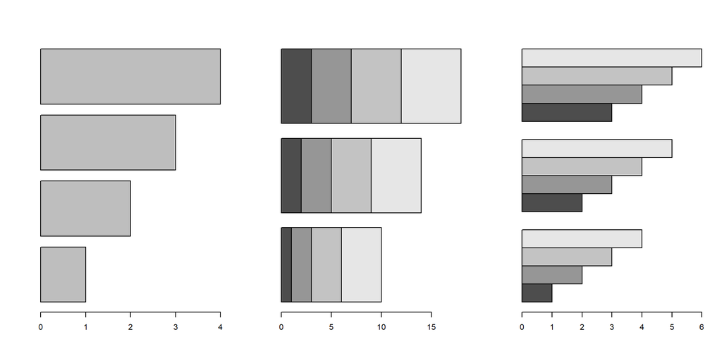

```r
par(mfrow=c(1,3))
x=1:4
barplot(x,horiz=TRUE)
xx=cbind(1:4,2:5,3:6)
barplot(xx,horiz=TRUE)
barplot(xx,horiz=TRUE,beside=TRUE)
```

Podobnie, jak w przypadku wykresów kołowych, argumentem tej funkcji nie może byc czynnik.